# Applying aLMI-X (`Xarray`-based Python aLMI code) to the GA Aquatic ARD database

- **Author**: Eric.Lehmann@csiro.au (based on the work of Stephen Sagar at GA)
- **Release date**: June 2021
- **Release version**: v1.0
- **Contents**:
  - Background
  - Setting up the modules and tools
  - Selecting a study region
  - Applying the Python-aLMI-X code to Sentinel-2 data
    - Connect to the Aquatic ARD datacube
    - Set up a data query and load the data
    - Applying aLMI to the Sentinel-2 data
    - Plotting the results
  - Testing Python-aLMI-X with MODIS data
    - Loading and processing the data
    - Applying aLMI to the MODIS data
    - Plotting the MODIS results

# Background

This notebook demonstrates the application of the Python aLMI algorithm in conjunction with the GA test database of Aquatic ARD data, produced for a selection of Landsat 8 OLI and Sentinel 2 MSI scenes for inland water bodies in Australia.

This notebook is primarily used to check the functionality of the `Xarray`-based Python implementation of the aLMI code. The first half uses an example of aLMI applied to a dataset of Sentinel-2B data acquired on 2020-07-16 over Lake Burrinjuck. The `.ini` file and SIOP datasets for this scenario were provided by Nathan Drayson.

The second half of the notebook applies aLMI to an example MODIS dataset loaded from a .nc file (i.e. not extracted from a datacube instance), which replicates the tests used earlier in the development of the Python version of the aLMI code.

# Setting up the modules and tools

```python
import xarray as xr
import numpy as np
import sys
import matplotlib.pyplot as plt
import datacube

# access to DEA tools:
sys.path.insert(1, '../steve_notebook/dea-notebooks-stevesagar/Tools/')
import dea_tools.plotting  # or some other submodule
import dea_tools.datahandling
```

# Selecting a study region

Specify the study region and check the extent on the map display.

```python
#lat_range = (-35.003, -35.031)
#lon_range = (148.627, 148.655)
lat_range = (-34.92, -35.045)
lon_range = (148.568, 148.747)
```

```python
dea_tools.plotting.display_map(x=lon_range, y=lat_range)
```

[interactive chart not shown]

# Applying the Python-aLMI-X code to Sentinel-2 data

## Connect to the Aquatic ARD datacube

```python
dc = datacube.Datacube(env="water-atcor", config="/g/data/r78/dea-atmospheric-correction-over-water/datacube.conf")
```

Using Sentinel-2bas an example, you can view the product and measurements available as follows.

```python
product = "ga_s2bm_aard_2"

measurements = dc.list_measurements()
measurements.loc[product]
```

| measurement | name | dtype | units | nodata | aliases | flags_definition | spectral_definition |
| --- | --- | --- | --- | --- | --- | --- | --- |
| lmbskyg_coastal_aerosol | lmbskyg_coastal_aerosol | int16 | 1 | -999 | [lmbskyg_band01, lmbskyg_coastal_aerosol] | NaN | NaN |
| lmbskyg_blue | lmbskyg_blue | int16 | 1 | -999 | [lmbskyg_band02, lmbskyg_blue] | NaN | NaN |
| lmbskyg_green | lmbskyg_green | int16 | 1 | -999 | [lmbskyg_band03, lmbskyg_green] | NaN | NaN |
| lmbskyg_red | lmbskyg_red | int16 | 1 | -999 | [lmbskyg_band04, lmbskyg_red] | NaN | NaN |
| lmbskyg_red_edge_1 | lmbskyg_red_edge_1 | int16 | 1 | -999 | [lmbskyg_band05, lmbskyg_red_edge_1] | NaN | NaN |
| lmbskyg_red_edge_2 | lmbskyg_red_edge_2 | int16 | 1 | -999 | [lmbskyg_band06, lmbskyg_red_edge_2] | NaN | NaN |
| lmbskyg_red_edge_3 | lmbskyg_red_edge_3 | int16 | 1 | -999 | [lmbskyg_band07, lmbskyg_red_edge_3] | NaN | NaN |
| lmbskyg_nir_1 | lmbskyg_nir_1 | int16 | 1 | -999 | [lmbskyg_band08, lmbskyg_nir_1] | NaN | NaN |
| lmbskyg_nir_2 | lmbskyg_nir_2 | int16 | 1 | -999 | [lmbskyg_band08a, lmbskyg_nir_2] | NaN | NaN |
| lmbskyg_swir_2 | lmbskyg_swir_2 | int16 | 1 | -999 | [lmbskyg_band11, lmbskyg_swir_2] | NaN | NaN |
| lmbskyg_swir_3 | lmbskyg_swir_3 | int16 | 1 | -999 | [lmbskyg_band12, lmbskyg_swir_3] | NaN | NaN |
| oa_fmask | oa_fmask | uint8 | 1 | 0 | [fmask, oa_fmask] | {'fmask': {'bits': [0, 1, 2, 3, 4, 5, 6, 7], '... | NaN |
| oa_combined_terrain_shadow | oa_combined_terrain_shadow | uint8 | 1 | 255 | [oa_combined_terrain_shadow] | {'contiguous': {'bits': [0], 'values': {'0': F... | NaN |
| oa_azimuthal_exiting | oa_azimuthal_exiting | float32 | 1 | NaN | [oa_azimuthal_exiting] | NaN | NaN |
| oa_azimuthal_incident | oa_azimuthal_incident | float32 | 1 | NaN | [oa_azimuthal_incident] | NaN | NaN |
| oa_exiting_angle | oa_exiting_angle | float32 | 1 | NaN | [oa_exiting_angle] | NaN | NaN |
| oa_incident_angle | oa_incident_angle | float32 | 1 | NaN | [oa_incident_angle] | NaN | NaN |
| oa_relative_azimuth | oa_relative_azimuth | float32 | 1 | NaN | [oa_relative_azimuth] | NaN | NaN |
| oa_relative_slope | oa_relative_slope | float32 | 1 | NaN | [oa_relative_slope] | NaN | NaN |
| oa_satellite_azimuth | oa_satellite_azimuth | float32 | 1 | NaN | [oa_satellite_azimuth] | NaN | NaN |
| oa_satellite_view | oa_satellite_view | float32 | 1 | NaN | [oa_satellite_view] | NaN | NaN |
| oa_solar_azimuth | oa_solar_azimuth | float32 | 1 | NaN | [oa_solar_azimuth] | NaN | NaN |
| oa_solar_zenith | oa_solar_zenith | float32 | 1 | NaN | [oa_solar_zenith] | NaN | NaN |
| oa_time_delta | oa_time_delta | float32 | 1 | NaN | [oa_time_delta] | NaN | NaN |

The `ga_s2bm_aard_2` product is comprised of the following sub-products:

- lmbskyg `lambertian sky glint corrected`
- oa `observation attributes`

## Set up a data query and load the data

```python
query = {
    #'product': 'ga_s2am_aard_2',
    'product': 'ga_s2bm_aard_2',    # option to search Sentinel 2b
    #'product': 'ga_ls8c_aard_3',   # option to search Landsat 8
    #'region_code':'55HBT',         # option to use Sentinel 2 granule ID or LS path/row
    'x': lon_range,
    'y': lat_range,
    'time': ('2020-07-15', '2020-07-17'),
    'output_crs': 'epsg:3577',
    'resolution': (-20, 20)
}
```

```python
ds = dc.load(**query)
ds = ds.where(ds.oa_fmask.isin([1, 5])) #retain only valid water pixels using fmask, masking clouds
```

The dataset `ds` of RS data can be displayed as shown below – the data variables within this dataset can be further inspected by opening the drop-down list of variables (small triangle to the left of `Data variables`) if needed, and clicking on the `attributes` and `data` icons on each line in the list of variables.

But first, let's only retain the variables of interest:

```python
keep_vars = list(ds.coords)   # keep coordinate vars
ds_vars = list(ds.variables)
band_vars = [bb for bb in ds_vars if bb.startswith('lmbskyg')]
keep_vars.extend( band_vars )
keep_vars.extend( ['oa_solar_zenith'] )

ds = ds[keep_vars]
ds
```

```
<xarray.Dataset>
Dimensions:                  (time: 1, x: 899, y: 797)
Coordinates:
  * time                     (time) datetime64[ns] 2020-07-16T00:16:25.252306
  * y                        (y) float64 -3.911e+06 -3.911e+06 ... -3.927e+06
  * x                        (x) float64 1.503e+06 1.503e+06 ... 1.521e+06
    spatial_ref              int32 3577
Data variables:
    lmbskyg_coastal_aerosol  (time, y, x) float64 -999.0 -999.0 ... -999.0
    lmbskyg_blue             (time, y, x) float64 -999.0 -999.0 ... -999.0
    lmbskyg_green            (time, y, x) float64 -999.0 -999.0 ... -999.0
    lmbskyg_red              (time, y, x) float64 -999.0 -999.0 ... -999.0
    lmbskyg_red_edge_1       (time, y, x) float64 -999.0 -999.0 ... -999.0
    lmbskyg_red_edge_2       (time, y, x) float64 -999.0 -999.0 ... -999.0
    lmbskyg_red_edge_3       (time, y, x) float64 -999.0 -999.0 ... -999.0
    lmbskyg_nir_1            (time, y, x) float64 -999.0 -999.0 ... -999.0
    lmbskyg_nir_2            (time, y, x) float64 -999.0 -999.0 ... -999.0
    lmbskyg_swir_2           (time, y, x) float64 -999.0 -999.0 ... -999.0
    lmbskyg_swir_3           (time, y, x) float64 -999.0 -999.0 ... -999.0
    oa_solar_zenith          (time, y, x) float32 62.523327 ... 62.53722
Attributes:
    crs:           epsg:3577
    grid_mapping:  spatial_ref
```

Replace `nodata` values witn NaN, and scale the data:

```python
for vv in band_vars:
    ds[vv] = ds[vv].where(ds[vv]!=ds[vv].nodata) * 0.0001 * np.pi
ds
```

```
<xarray.Dataset>
Dimensions:                  (time: 1, x: 899, y: 797)
Coordinates:
  * time                     (time) datetime64[ns] 2020-07-16T00:16:25.252306
  * y                        (y) float64 -3.911e+06 -3.911e+06 ... -3.927e+06
  * x                        (x) float64 1.503e+06 1.503e+06 ... 1.521e+06
    spatial_ref              int32 3577
Data variables:
    lmbskyg_coastal_aerosol  (time, y, x) float64 nan nan nan ... nan nan nan
    lmbskyg_blue             (time, y, x) float64 nan nan nan ... nan nan nan
    lmbskyg_green            (time, y, x) float64 nan nan nan ... nan nan nan
    lmbskyg_red              (time, y, x) float64 nan nan nan ... nan nan nan
    lmbskyg_red_edge_1       (time, y, x) float64 nan nan nan ... nan nan nan
    lmbskyg_red_edge_2       (time, y, x) float64 nan nan nan ... nan nan nan
    lmbskyg_red_edge_3       (time, y, x) float64 nan nan nan ... nan nan nan
    lmbskyg_nir_1            (time, y, x) float64 nan nan nan ... nan nan nan
    lmbskyg_nir_2            (time, y, x) float64 nan nan nan ... nan nan nan
    lmbskyg_swir_2           (time, y, x) float64 nan nan nan ... nan nan nan
    lmbskyg_swir_3           (time, y, x) float64 nan nan nan ... nan nan nan
    oa_solar_zenith          (time, y, x) float32 62.523327 ... 62.53722
Attributes:
    crs:           epsg:3577
    grid_mapping:  spatial_ref
```

Plot an RGB representation of this dataset:

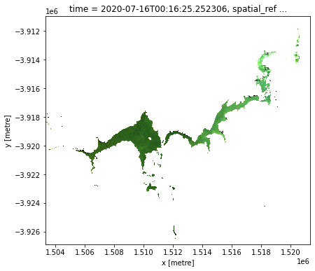

```python
dea_tools.plotting.rgb( ds, index=0,
                        bands=['lmbskyg_red','lmbskyg_green','lmbskyg_blue'],
                        percentile_stretch=['0.01', '0.98'] )
```

## Applying aLMI to the Sentinel-2 data

The updated Python aLMI code takes an Xarray dataset as input, such as the `ds` dataset we've just loaded above. The code currently expects this dataset to contain at most one single time slice – a multi-temporal `Xarray` dataset will not be accepted.

In addition, the code requires a file of input parameters (`.ini` file), containing various parameters and options that will be used during the processing of the data with aLMI.

```python
# import the main aLMI function:
from aLMI_main import aLMI_main
```

```python
# define the path to the config .ini file:
# CONFIG_FILE = "./ini_files/aLMI_config_testVDI_S2.ini"
CONFIG_FILE = "./ini_files/burj_aLMI_config_test.ini"
!cat {CONFIG_FILE}
```

```
# This is the config file for the aLMI.
# It is read into python using the ConfigParser module that is in the python base package.
# Note that section names are case-sensitive, while parameter names are case-insensitive.

[inputParameters]

SIOP_SETS_FILE = ./data/burj_test_siops_S2_wls.nc

# NOTE: these variable names MUST match the names in the ANN file used as input to aLMI!
# inputSpectrumVarNames = ["Rrs_ANN_412" , "Rrs_ANN_443" , "Rrs_ANN_488" , "Rrs_ANN_531" , "Rrs_ANN_547" , "Rrs_ANN_667" , "Rrs_ANN_678" , "Rrs_ANN_748" ]
inputSpectrumVarNames = ['lmbskyg_coastal_aerosol', 'lmbskyg_blue', 'lmbskyg_green','lmbskyg_red', 'lmbskyg_red_edge_1', 'lmbskyg_red_edge_2','lmbskyg_red_edge_3' ]

# NOTE: useWavelengths must have same count as inputSpectrumVarNames
useWavelengths =        [442.7, 492.4, 559.8, 664.6, 704.1, 740.5, 782.8]
tolerance = 5.0
# (nm)

# components: must contain some or all of "CHL", "CDOM", "NAP"
components = ["CHL", "CDOM", "NAP"]

chunkProcessConfig = {'costType':'RMSE', 'minValidConc':0.00001, 'outputFillValue':-999., 'costThreshhold':100.}

# Possible types are reflAboveSurf|reflBelowSurf|uIopRatio
inputType = reflAboveSurf

SolarZenithBandName = oa_solar_zenith

numberOfLinesPerChunk = 500

verbosity = 1


[outputParameters]

outWavelengthLabels =   [ "442.7", "492.4", "559.8", "664.6", "704.1", "740.5", "782.8"]
# NOTE: outWavelengthLabels must have same count as inputSpectrumVarNames
#       outWavelengthLabels values must be within tolerance of useWavelengths (corresponding array values)

# Possible types are reflAboveSurf|reflBelowSurf|uIopRatio|""    (if "", then outputType is inputType)
outputType = ""
```

[output cut: 43 more lines]

```

#from Lee 1999 AO
g1Lee = 0.17
g0Lee = 0.084
#from Lee 2002 AO
g1QAA = 0.1247
g0QAA = 0.0895
#from Gordon 1988
g1Gordon = 0.079
g0Gordon = 0.094

ggLee = "    0.084    0.17"
# multiple values

g0LeeFloat = 0.084
```

**Note**  
In the above `.ini` file, the bottom of the range of Kd wavelengths `Kd_WavelengthsRange` had to be changed from 420 to 440 as the 10nm file used here starts at 442nm.

The aLMI code can be applied to the current `ds` dataset (`Xarray`) as follows:

```python
%%time
out_ds = aLMI_main(ds, CONFIG_FILE)
```

```
ipykernel_launcher.py:  startTime = 2021-06-04 05:18:27.986039 UTC
The config file to be used is:  ./ini_files/burj_aLMI_config_test.ini
Verbosity level =  1
process input as reflAboveSurf
output will be reflAboveSurf; output variable prefix will be Rrs_MIM_
Model constants (that capture the water's sun angle geometry and scattering phase functions):  g0 =  0.084  g1 =  0.17
Constituent concentrations requested:  ['CHL', 'CDOM', 'NAP']
Cost function type =  RMSE
Min valid conc =  1e-05
OutputFillValue =  -999.0
CostThreshhold (accepted pixels must have a cost < costThreshhold) =  100.0
SIOP_sets_load:  using generic_io from /home/599/eal599/Eric_VDI/iWQ_aLMI/Python-aLMI-X/generic_io.py
Using SIOP sets from ./data/burj_test_siops_S2_wls.nc
Using these SIOP wavelengths:  [     442.700012      492.399994      559.799988      664.599976      704.099976      740.500000      782.799988]
SIOP_sets_load:  using generic_io from /home/599/eal599/Eric_VDI/iWQ_aLMI/Python-aLMI-X/generic_io.py
Using 10nm SIOP sets from ./data/burj_test_siops_10nm_int_wls.nc
Using these SIOP wavelengths:  [     442.000000      452.000000      462.000000      472.000000      482.000000      492.000000      502.000000      512.000000      522.000000
      532.000000      542.000000      552.000000      562.000000      572.000000      582.000000      592.000000      602.000000      612.000000
      622.000000      632.000000      642.000000      652.000000      662.000000      672.000000      682.000000      692.000000      702.000000
      712.000000      722.000000      732.000000      742.000000      752.000000]
Channel SIOP set names:  ['BURJ_01-20-03-1', 'BURJ_01-20-07-1', 'BURJ_03-20-07-1', 'BURJ_01-20-09-1', 'BURJ_02-20-09-1']
10nm    SIOP set names:  ['BURJ_01-20-03-1', 'BURJ_01-20-07-1', 'BURJ_03-20-07-1', 'BURJ_01-20-09-1', 'BURJ_02-20-09-1']
490 found at index 5 in [440, 450, 460, 470, 480, 490, 500, 510, 520, 530, 540, 550, 560, 570, 580, 590, 600, 610, 620, 630, 640, 650, 660, 670, 680, 690, 700, 710, 720, 730, 740, 750]
442.7 found at index 0 in ['442.7', '492.4', '559.8', '664.6', '704.1', '740.5', '782.8']
559.8 found at index 2 in ['442.7', '492.4', '559.8', '664.6', '704.1', '740.5', '782.8']
CHL found at index 0 in ['CHL', 'CDOM', 'NAP']
CDOM found at index 1 in ['CHL', 'CDOM', 'NAP']
NAP found at index 2 in ['CHL', 'CDOM', 'NAP']
The input spectrum variable names in the input dataset are ['lmbskyg_coastal_aerosol', 'lmbskyg_blue', 'lmbskyg_green', 'lmbskyg_red', 'lmbskyg_red_edge_1', 'lmbskyg_red_edge_2', 'lmbskyg_red_edge_3']
The spectrum variable names in the aLMI output dataset will be ['Rrs_MIM_442.7', 'Rrs_MIM_492.4', 'Rrs_MIM_559.8', 'Rrs_MIM_664.6', 'Rrs_MIM_704.1', 'Rrs_MIM_740.5', 'Rrs_MIM_782.8']
fv = -999.0
--- Processing chunk 1 of 2 :  1  to end of the chunk:  500
Number of valid pixels = 12402
inputValid_WL_EL.shape = (7, 12402)
input_WL_LINE_PIX.shape = (7, 500, 899)
input_WL_EL.shape = (7, 449500)
shape of results from chunkProcessLMI are:
	cost.shape:  (12402,)
	SIOPindex.shape:  (12402,)
	conc.shape:  (3, 12402)
	absTotal.shape:  (7, 12402)
	backscatTotal.shape:  (7, 12402)
	abs.shape:  (7, 3, 12402)
	backscat.shape:  (7, 3, 12402)
	uIOPRatio.shape:  (7, 12402)
	uIOPRatioPredicted.shape:  (7, 12402)
	reflBelowSurfPredicted.shape:  (7, 12402)
	deltaReflBelowSurf.shape:  (7, 12402)
--- Processing chunk 2 of 2 :  501  to end of the chunk:  797
Number of valid pixels = 163
ipykernel_launcher.py done
CPU times: user 4.28 s, sys: 297 ms, total: 4.58 s
Wall time: 4.63 s
```

And here is the resulting output dataset – the data variables can be inspected by clicking on the drop-down icon next to `Data variables`:

```python
out_ds
```

```
<xarray.Dataset>
Dimensions:                    (x: 899, y: 797)
Coordinates:
    spatial_ref                int32 3577
  * y                          (y) float64 -3.911e+06 -3.911e+06 ... -3.927e+06
  * x                          (x) float64 1.503e+06 1.503e+06 ... 1.521e+06
Data variables:
    CHL_MIM                    (y, x) float32 -999.0 -999.0 ... -999.0 -999.0
    CDOM_MIM                   (y, x) float32 -999.0 -999.0 ... -999.0 -999.0
    NAP_MIM                    (y, x) float32 -999.0 -999.0 ... -999.0 -999.0
    SIOPindex                  (y, x) int16 -999 -999 -999 ... -999 -999 -999
    cost_Rrs_below             (y, x) float32 -999.0 -999.0 ... -999.0 -999.0
    a_phy_MIM_442.7            (y, x) float32 -999.0 -999.0 ... -999.0 -999.0
    a_CDOM_MIM_442.7           (y, x) float32 -999.0 -999.0 ... -999.0 -999.0
    a_NAP_MIM_442.7            (y, x) float32 -999.0 -999.0 ... -999.0 -999.0
    a_P_MIM_442.7              (y, x) float32 -999.0 -999.0 ... -999.0 -999.0
    a_CDM_MIM_442.7            (y, x) float32 -999.0 -999.0 ... -999.0 -999.0
    a_tot_MIM_442.7            (y, x) float32 -999.0 -999.0 ... -999.0 -999.0
    bb_phy_MIM_559.8           (y, x) float32 -999.0 -999.0 ... -999.0 -999.0
    bb_NAP_MIM_559.8           (y, x) float32 -999.0 -999.0 ... -999.0 -999.0
    bb_P_MIM_559.8             (y, x) float32 -999.0 -999.0 ... -999.0 -999.0
    Kd_par_MIM                 (y, x) float32 -999.0 -999.0 ... -999.0 -999.0
    Kd_490_MIM                 (y, x) float32 -999.0 -999.0 ... -999.0 -999.0
    SD_MIM                     (y, x) float32 -999.0 -999.0 ... -999.0 -999.0
    Rrs_MIM_442.7              (y, x) float32 -999.0 -999.0 ... -999.0 -999.0
    Rrs_MIM_492.4              (y, x) float32 -999.0 -999.0 ... -999.0 -999.0
    Rrs_MIM_559.8              (y, x) float32 -999.0 -999.0 ... -999.0 -999.0
    Rrs_MIM_664.6              (y, x) float32 -999.0 -999.0 ... -999.0 -999.0
    Rrs_MIM_704.1              (y, x) float32 -999.0 -999.0 ... -999.0 -999.0
    Rrs_MIM_740.5              (y, x) float32 -999.0 -999.0 ... -999.0 -999.0
    Rrs_MIM_782.8              (y, x) float32 -999.0 -999.0 ... -999.0 -999.0
    Delta_Rrs_below_MIM_442.7  (y, x) float32 -999.0 -999.0 ... -999.0 -999.0
    Delta_Rrs_below_MIM_492.4  (y, x) float32 -999.0 -999.0 ... -999.0 -999.0
    Delta_Rrs_below_MIM_559.8  (y, x) float32 -999.0 -999.0 ... -999.0 -999.0
    Delta_Rrs_below_MIM_664.6  (y, x) float32 -999.0 -999.0 ... -999.0 -999.0
    Delta_Rrs_below_MIM_704.1  (y, x) float32 -999.0 -999.0 ... -999.0 -999.0
    Delta_Rrs_below_MIM_740.5  (y, x) float32 -999.0 -999.0 ... -999.0 -999.0
    Delta_Rrs_below_MIM_782.8  (y, x) float32 -999.0 -999.0 ... -999.0 -999.0
Attributes:
    crs:           epsg:3577
    grid_mapping:  spatial_ref
```

## Plotting the results

We can plot the aLMI results (all outputs) as follows.

```python
nvars = len(out_ds.data_vars)
```

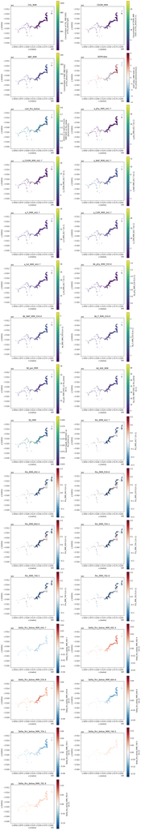

```python
ncols = 2
mm,rr = divmod(nvars,ncols)
nrows = mm + int(rr!=0)

fig, axs = plt.subplots(nrows, ncols, figsize=(12,70))
axs = axs.flat   # axs.reshape(-1)   # "flatten" the list of axes

for ii,vv in enumerate( list(out_ds.data_vars) ):
    ndv = out_ds[vv].attrs['nodata']  # no data value
    plt.sca(axs[ii]); axs[ii].set_aspect('equal')
    out_ds[vv].where(out_ds[vv]!=ndv).plot()
    plt.title(vv); plt.tight_layout()

for kk in range(ii+1,(nrows*ncols)): axs[kk].set_axis_off()   # "kill" superfluous axes...
```

Further plot of the `SIOPindex` output:

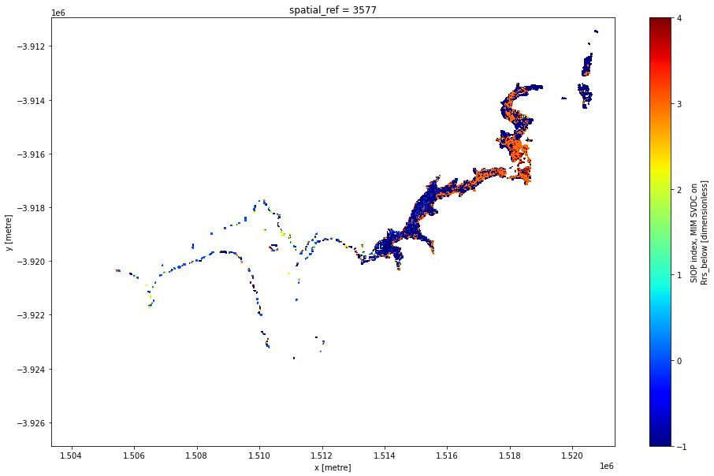

```python
# Replace 'nodata' with NaN:
tmp = out_ds.SIOPindex.where(out_ds.SIOPindex!=out_ds.SIOPindex.nodata)

# Plot the result:
tmp.plot(vmin=-1.0, vmax=4.0, cmap='jet', figsize=(16,10));
```

# Testing Python-aLMI-X with MODIS data

For further insight, we can load up the `.nc` input file of MODIS data (used as a test dataset during the original translation of the aLMI code to Python3) and apply aLMI to that dataset.

## Loading and processing the data

First read the test MODIS dataset from `.nc` into an `Xarray` dataset, and pre-process to ensure we can apply aLMI to it.

```python
nc_input_file = "/g/data/r78/aLMI/data/A20120403_0410.20150928173107.L2OC_BASE.ANN_P134_V20140704.nc"
nc_ds = xr.open_dataset(nc_input_file)
nc_ds
```

```
<xarray.Dataset>
Dimensions:      (number_of_lines: 2170, pixel_control_points: 1354, pixels_per_line: 1354, total_band_number: 9)
Dimensions without coordinates: number_of_lines, pixel_control_points, pixels_per_line, total_band_number
Data variables:
    msec         (number_of_lines) timedelta64[ns] 04:09:57.946000 ... 04:15:...
    longitude    (number_of_lines, pixel_control_points) float32 ...
    latitude     (number_of_lines, pixel_control_points) float32 ...
    Lt_412       (number_of_lines, pixels_per_line) float32 ...
    Lt_443       (number_of_lines, pixels_per_line) float32 ...
    Lt_488       (number_of_lines, pixels_per_line) float32 ...
    Lt_531       (number_of_lines, pixels_per_line) float32 ...
    Lt_547       (number_of_lines, pixels_per_line) float32 ...
    Lt_667       (number_of_lines, pixels_per_line) float32 ...
    Lt_678       (number_of_lines, pixels_per_line) float32 ...
    Lt_748       (number_of_lines, pixels_per_line) float32 ...
    Lt_869       (number_of_lines, pixels_per_line) float32 ...
    Rrs_412      (number_of_lines, pixels_per_line) float32 ...
    Rrs_443      (number_of_lines, pixels_per_line) float32 ...
    Rrs_488      (number_of_lines, pixels_per_line) float32 ...
    Rrs_531      (number_of_lines, pixels_per_line) float32 ...
    Rrs_547      (number_of_lines, pixels_per_line) float32 ...
    Rrs_667      (number_of_lines, pixels_per_line) float32 ...
    Rrs_678      (number_of_lines, pixels_per_line) float32 ...
    Rrs_748      (number_of_lines, pixels_per_line) float32 ...
    Rrs_869      (number_of_lines, pixels_per_line) float32 ...
    Rrs_ANN_412  (number_of_lines, pixels_per_line) float32 ...
    Rrs_ANN_443  (number_of_lines, pixels_per_line) float32 ...
    Rrs_ANN_488  (number_of_lines, pixels_per_line) float32 ...
    Rrs_ANN_531  (number_of_lines, pixels_per_line) float32 ...
    Rrs_ANN_547  (number_of_lines, pixels_per_line) float32 ...
    Rrs_ANN_667  (number_of_lines, pixels_per_line) float32 ...
    Rrs_ANN_678  (number_of_lines, pixels_per_line) float32 ...
    Rrs_ANN_748  (number_of_lines, pixels_per_line) float32 ...
    zen          (number_of_lines, pixels_per_line) float32 ...
    azi          (number_of_lines, pixels_per_line) float32 ...
    obs          (number_of_lines, pixels_per_line) float32 ...
    l2_flags     (number_of_lines, pixels_per_line) int32 ...
    nn_flags     (number_of_lines, pixels_per_line) int32 ...
    wavelength   (total_band_number) int16 412 443 488 531 547 667 678 748 869
Attributes:
    ATMCORR_VERSION:  ANN_P134_V20140704
    CREATION_DATE:    2015-12-18 01:19:49.346178 UTC
    CREATOR:          kds599
    EMAIL_ADDRESS:    unknown
    script:           run_ANN.py
    ANN_version:      net_014_0_080_1_000_1_012_0_00_11_P134
```

```python
list(nc_ds.dims)
```

```
['number_of_lines',
 'pixel_control_points',
 'pixels_per_line',
 'total_band_number']
```

The list of dimensions of this dataset includes several "coordinates" that can't be used as input ot aLMI-X – the code expects an input dataset with only two dimensions (`x`/`y`, `lat`/`lon`, etc.).

Let's remove the (unnecessary) variables in the `.nc`-based dataset that make use of the superfluous dimensions – the resulting dataset will then only contain the dimensions of interest.

```python
nc_ds = nc_ds.drop_vars(['latitude','longitude','wavelength']).squeeze(drop=True)
print( "The dataset's dimensions are now: ", list(nc_ds.dims) )
nc_ds
```

```
The dataset's dimensions are now:  ['number_of_lines', 'pixels_per_line']
```

```
<xarray.Dataset>
Dimensions:      (number_of_lines: 2170, pixels_per_line: 1354)
Dimensions without coordinates: number_of_lines, pixels_per_line
Data variables:
    msec         (number_of_lines) timedelta64[ns] 04:09:57.946000 ... 04:15:...
    Lt_412       (number_of_lines, pixels_per_line) float32 ...
    Lt_443       (number_of_lines, pixels_per_line) float32 ...
    Lt_488       (number_of_lines, pixels_per_line) float32 ...
    Lt_531       (number_of_lines, pixels_per_line) float32 ...
    Lt_547       (number_of_lines, pixels_per_line) float32 ...
    Lt_667       (number_of_lines, pixels_per_line) float32 ...
    Lt_678       (number_of_lines, pixels_per_line) float32 ...
    Lt_748       (number_of_lines, pixels_per_line) float32 ...
    Lt_869       (number_of_lines, pixels_per_line) float32 ...
    Rrs_412      (number_of_lines, pixels_per_line) float32 ...
    Rrs_443      (number_of_lines, pixels_per_line) float32 ...
    Rrs_488      (number_of_lines, pixels_per_line) float32 ...
    Rrs_531      (number_of_lines, pixels_per_line) float32 ...
    Rrs_547      (number_of_lines, pixels_per_line) float32 ...
    Rrs_667      (number_of_lines, pixels_per_line) float32 ...
    Rrs_678      (number_of_lines, pixels_per_line) float32 ...
    Rrs_748      (number_of_lines, pixels_per_line) float32 ...
    Rrs_869      (number_of_lines, pixels_per_line) float32 ...
    Rrs_ANN_412  (number_of_lines, pixels_per_line) float32 ...
    Rrs_ANN_443  (number_of_lines, pixels_per_line) float32 ...
    Rrs_ANN_488  (number_of_lines, pixels_per_line) float32 ...
    Rrs_ANN_531  (number_of_lines, pixels_per_line) float32 ...
    Rrs_ANN_547  (number_of_lines, pixels_per_line) float32 ...
    Rrs_ANN_667  (number_of_lines, pixels_per_line) float32 ...
    Rrs_ANN_678  (number_of_lines, pixels_per_line) float32 ...
    Rrs_ANN_748  (number_of_lines, pixels_per_line) float32 ...
    zen          (number_of_lines, pixels_per_line) float32 ...
    azi          (number_of_lines, pixels_per_line) float32 ...
    obs          (number_of_lines, pixels_per_line) float32 ...
    l2_flags     (number_of_lines, pixels_per_line) int32 ...
    nn_flags     (number_of_lines, pixels_per_line) int32 ...
Attributes:
    ATMCORR_VERSION:  ANN_P134_V20140704
    CREATION_DATE:    2015-12-18 01:19:49.346178 UTC
    CREATOR:          kds599
    EMAIL_ADDRESS:    unknown
    script:           run_ANN.py
    ANN_version:      net_014_0_080_1_000_1_012_0_00_11_P134
```

## Applying aLMI to the MODIS data

Given the new dataset of MODIS data, we need to point the aLMI code to a different `.ini` file of input parameters (MODIS-based, rather than Sentinel-2 parameters):

```python
CONFIG_FILE = "./ini_files/aLMI_config_testVDI_MODIS.ini"
!cat {CONFIG_FILE}
```

```
# This is the config file for the aLMI -- for test MODIS .nc file on VDI
# It is read into python using the ConfigParser module that is in the python base package.
# Note that section names are case-sensitive, while parameter names are case-insensitive.
#
# Config file updated for .nc file input to aLMI.

[inputParameters]

SIOP_SETS_FILE = ./data/siops_MODIS_all_CLT4.nc

# NOTE: these variable names MUST match the names in the ANN file used as input to aLMI!
inputSpectrumVarNames = ["Rrs_ANN_412" , "Rrs_ANN_443" , "Rrs_ANN_488" , "Rrs_ANN_531" , "Rrs_ANN_547" , "Rrs_ANN_667" , "Rrs_ANN_678" , "Rrs_ANN_748" ]

# NOTE: useWavelengths must have same count as inputSpectrumVarNames
useWavelengths =        [         411.5,          441.5,          486.5,          528.5,          551.0,          665.5,          676.5,          746.5]
tolerance = 5.0
# (nm)

# components: must contain some or all of "CHL", "CDOM", "NAP"
components = ["CHL", "CDOM", "NAP"]

chunkProcessConfig = {'costType':'RMSE', 'minValidConc':0.00001, 'outputFillValue':-999., 'costThreshhold':100.}

# Possible types are reflAboveSurf|reflBelowSurf|uIopRatio
inputType = reflBelowSurf

SolarZenithBandName = zen

numberOfLinesPerChunk = 500

verbosity = 1


[outputParameters]

outWavelengthLabels =   [    "412" ,     "441" ,     "488" ,     "531" ,     "551" ,     "667" ,     "678" ,     "748" ]
# NOTE: outWavelengthLabels must have same count as inputSpectrumVarNames
#       outWavelengthLabels values must be within tolerance of useWavelengths (corresponding array values)

# Possible types are reflAboveSurf|reflBelowSurf|uIopRatio|""    (if "", then outputType is inputType)
```

[output cut: 43 more lines]

```

#from Lee 1999 AO
g1Lee = 0.17
g0Lee = 0.084
#from Lee 2002 AO
g1QAA = 0.1247
g0QAA = 0.0895
#from Gordon 1988
g1Gordon = 0.079
g0Gordon = 0.094

ggLee = "    0.084    0.17"
# multiple values

g0LeeFloat = 0.084
```

```python
# Run the aLMI code on the MODIS dataset:
out_ds = aLMI_main(nc_ds, CONFIG_FILE)
```

```
ipykernel_launcher.py:  startTime = 2021-06-04 05:19:53.576780 UTC
The config file to be used is:  ./ini_files/aLMI_config_testVDI_MODIS.ini
Verbosity level =  1
process input as reflBelowSurf
output will be reflAboveSurf; output variable prefix will be Rrs_MIM_
Model constants (that capture the water's sun angle geometry and scattering phase functions):  g0 =  0.084  g1 =  0.17
Constituent concentrations requested:  ['CHL', 'CDOM', 'NAP']
Cost function type =  RMSE
Min valid conc =  1e-05
OutputFillValue =  -999.0
CostThreshhold (accepted pixels must have a cost < costThreshhold) =  100.0
SIOP_sets_load:  using generic_io from /home/599/eal599/Eric_VDI/iWQ_aLMI/Python-aLMI-X/generic_io.py
Using SIOP sets from ./data/siops_MODIS_all_CLT4.nc
Using these SIOP wavelengths:  [     411.500000      441.500000      486.500000      528.500000      546.500000      665.500000      676.500000      746.500000]
SIOP_sets_load:  using generic_io from /home/599/eal599/Eric_VDI/iWQ_aLMI/Python-aLMI-X/generic_io.py
Using 10nm SIOP sets from ./data/siops_10nm_all_CLT4.nc
Using these SIOP wavelengths:  [     424.500000      434.500000      444.500000      454.500000      464.500000      474.500000      484.500000      494.500000      504.500000
      514.500000      524.500000      534.500000      544.500000      554.500000      564.500000      574.500000      584.500000      594.500000
      604.500000      614.500000      624.500000      634.500000      644.500000      654.500000      664.500000      674.500000      684.500000
      694.500000      704.500000      714.500000      724.500000      734.500000      744.500000      754.500000]
Channel SIOP set names:  ['GBR_CLU4_01', 'GBR_CLU4_02', 'GBR_CLU4_04', 'GBR_CLU4_05', 'GBR_CLU4_06', 'GBR_CLU4_08', 'GBR_CLU4_09', 'GBR_CLU4_10']
10nm    SIOP set names:  ['GBR_CLU4_01', 'GBR_CLU4_02', 'GBR_CLU4_04', 'GBR_CLU4_05', 'GBR_CLU4_06', 'GBR_CLU4_08', 'GBR_CLU4_09', 'GBR_CLU4_10']
490 found at index 7 in [420, 430, 440, 450, 460, 470, 480, 490, 500, 510, 520, 530, 540, 550, 560, 570, 580, 590, 600, 610, 620, 630, 640, 650, 660, 670, 680, 690, 700, 710, 720, 730, 740, 750]
441 found at index 1 in ['412', '441', '488', '531', '551', '667', '678', '748']
551 found at index 4 in ['412', '441', '488', '531', '551', '667', '678', '748']
CHL found at index 0 in ['CHL', 'CDOM', 'NAP']
CDOM found at index 1 in ['CHL', 'CDOM', 'NAP']
NAP found at index 2 in ['CHL', 'CDOM', 'NAP']
The input spectrum variable names in the input dataset are ['Rrs_ANN_412', 'Rrs_ANN_443', 'Rrs_ANN_488', 'Rrs_ANN_531', 'Rrs_ANN_547', 'Rrs_ANN_667', 'Rrs_ANN_678', 'Rrs_ANN_748']
The spectrum variable names in the aLMI output dataset will be ['Rrs_MIM_412', 'Rrs_MIM_441', 'Rrs_MIM_488', 'Rrs_MIM_531', 'Rrs_MIM_551', 'Rrs_MIM_667', 'Rrs_MIM_678', 'Rrs_MIM_748']
fv = -999.0
--- Processing chunk 1 of 5 :  1  to end of the chunk:  500
Number of valid pixels = 156477
inputValid_WL_EL.shape = (8, 156477)
input_WL_LINE_PIX.shape = (8, 500, 1354)
input_WL_EL.shape = (8, 677000)
shape of results from chunkProcessLMI are:
	cost.shape:  (156477,)
	SIOPindex.shape:  (156477,)
	conc.shape:  (3, 156477)
	absTotal.shape:  (8, 156477)
	backscatTotal.shape:  (8, 156477)
	abs.shape:  (8, 3, 156477)
	backscat.shape:  (8, 3, 156477)
	uIOPRatio.shape:  (8, 156477)
	uIOPRatioPredicted.shape:  (8, 156477)
	reflBelowSurfPredicted.shape:  (8, 156477)
	deltaReflBelowSurf.shape:  (8, 156477)
--- Processing chunk 2 of 5 :  501  to end of the chunk:  1000
Number of valid pixels = 287179
--- Processing chunk 3 of 5 :  1001  to end of the chunk:  1500
Number of valid pixels = 183360
--- Processing chunk 4 of 5 :  1501  to end of the chunk:  2000
Number of valid pixels = 79104
--- Processing chunk 5 of 5 :  2001  to end of the chunk:  2170
Number of valid pixels = 33294
ipykernel_launcher.py done
```

And here is the resulting `Xarray` output dataset (click on the `Data variables` drop-down to see the variables generated by aLMI):

```python
out_ds
```

```
<xarray.Dataset>
Dimensions:                  (number_of_lines: 2170, pixels_per_line: 1354)
Dimensions without coordinates: number_of_lines, pixels_per_line
Data variables:
    CHL_MIM                  (number_of_lines, pixels_per_line) float32 -999....
    CDOM_MIM                 (number_of_lines, pixels_per_line) float32 -999....
    NAP_MIM                  (number_of_lines, pixels_per_line) float32 -999....
    SIOPindex                (number_of_lines, pixels_per_line) int16 -999 .....
    cost_Rrs_below           (number_of_lines, pixels_per_line) float32 -999....
    a_phy_MIM_441            (number_of_lines, pixels_per_line) float32 -999....
    a_CDOM_MIM_441           (number_of_lines, pixels_per_line) float32 -999....
    a_NAP_MIM_441            (number_of_lines, pixels_per_line) float32 -999....
    a_P_MIM_441              (number_of_lines, pixels_per_line) float32 -999....
    a_CDM_MIM_441            (number_of_lines, pixels_per_line) float32 -999....
    a_tot_MIM_441            (number_of_lines, pixels_per_line) float32 -999....
    bb_phy_MIM_551           (number_of_lines, pixels_per_line) float32 -999....
    bb_NAP_MIM_551           (number_of_lines, pixels_per_line) float32 -999....
    bb_P_MIM_551             (number_of_lines, pixels_per_line) float32 -999....
    Kd_par_MIM               (number_of_lines, pixels_per_line) float32 -999....
    Kd_490_MIM               (number_of_lines, pixels_per_line) float32 -999....
    SD_MIM                   (number_of_lines, pixels_per_line) float32 -999....
    Rrs_MIM_412              (number_of_lines, pixels_per_line) float32 -999....
    Rrs_MIM_441              (number_of_lines, pixels_per_line) float32 -999....
    Rrs_MIM_488              (number_of_lines, pixels_per_line) float32 -999....
    Rrs_MIM_531              (number_of_lines, pixels_per_line) float32 -999....
    Rrs_MIM_551              (number_of_lines, pixels_per_line) float32 -999....
    Rrs_MIM_667              (number_of_lines, pixels_per_line) float32 -999....
    Rrs_MIM_678              (number_of_lines, pixels_per_line) float32 -999....
    Rrs_MIM_748              (number_of_lines, pixels_per_line) float32 -999....
    Delta_Rrs_below_MIM_412  (number_of_lines, pixels_per_line) float32 -999....
    Delta_Rrs_below_MIM_441  (number_of_lines, pixels_per_line) float32 -999....
    Delta_Rrs_below_MIM_488  (number_of_lines, pixels_per_line) float32 -999....
    Delta_Rrs_below_MIM_531  (number_of_lines, pixels_per_line) float32 -999....
    Delta_Rrs_below_MIM_551  (number_of_lines, pixels_per_line) float32 -999....
    Delta_Rrs_below_MIM_667  (number_of_lines, pixels_per_line) float32 -999....
    Delta_Rrs_below_MIM_678  (number_of_lines, pixels_per_line) float32 -999....
    Delta_Rrs_below_MIM_748  (number_of_lines, pixels_per_line) float32 -999....
Attributes:
    ATMCORR_VERSION:  ANN_P134_V20140704
    CREATION_DATE:    2015-12-18 01:19:49.346178 UTC
    CREATOR:          kds599
    EMAIL_ADDRESS:    unknown
    script:           run_ANN.py
    ANN_version:      net_014_0_080_1_000_1_012_0_00_11_P134
```

## Plotting the MODIS results

```python
### The following plots all variables in a facet grid with *common* colour bar...
# ndv = out_ds.CHL_MIM.attrs['nodata']  # no data value
# tmp = out_ds.to_array()
# tmp = tmp.where(tmp!=ndv)
# tmp.plot(col='variable', col_wrap=3);
```

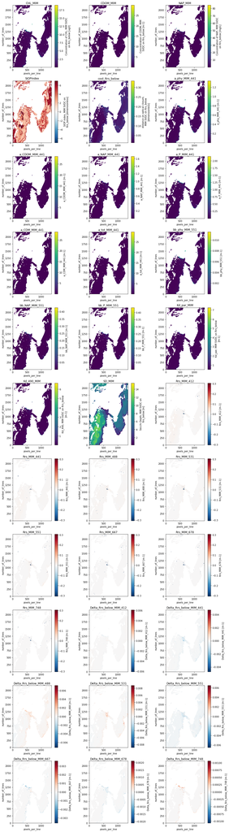

```python
nvars = len(list(out_ds.data_vars))
ncols = 3
mm,rr = divmod(nvars,ncols)
nrows = mm + int(rr!=0)

fig, axs = plt.subplots(nrows, ncols, figsize=(14,50))
axs = axs.flat   # "flatten" the list of axes

for ii,vv in enumerate( list(out_ds.data_vars) ):
    ndv = out_ds[vv].attrs['nodata']  # no data value
    plt.sca(axs[ii]); axs[ii].set_aspect('equal')
    out_ds[vv].where(out_ds[vv]!=ndv).plot()
    plt.title(vv); plt.tight_layout()

for kk in range(ii+1,(nrows*ncols)): axs[kk].set_axis_off()   # kill superfluous axes...
```

```python
### End notebook
```